# MMRM - SAS versus R

## SAS code

In SAS the following code was used (assessments at avisitn=0 should also be removed from the response variable):

```
proc mixed data=adlbh;
  where base ne . and avisitn not in (., 99);
  class usubjid trtpn(ref="0") avisitn;
  by paramcd param;
  model chg=base trtpn avisitn  trtpn*avisitn / solution cl alpha=0.05 ddfm=KR;
  repeated avisitn/subject=usubjid type=&covar;
  lsmeans trtpn * avisitn / diff cl slice=avisitn;
  lsmeans trtpn / diff cl;
run;
```

where the macro variable covar could be UN, CS or AR(1). The results were stored in .csv files that were post-processed in R and compared with the results from R.

## R code using the gls function

The code below implements the MMRM using the gls function from the nlme package. Afterwards the emmeans package is used to get LSmeans estimates.

```
### Unstructured
mod1<-tryCatch(gls(model = CHG ~ TRTP + AVISITN + TRTP:AVISITN + AVISITN + BASE,
                   data = adlbh_1,
                   correlation = corSymm(form = ~1|SUBJID),
                   weights = varIdent(form = ~1|AVISITN),
                   control = glsControl(opt = "optim"),
                   method = "REML",
                   na.action = "na.omit"),
                   error = function(x) return(NULL))

### Compound symmetry
mod1<-tryCatch(gls(model = CHG ~ TRTP + AVISITN + TRTP:AVISITN + AVISITN + BASE,
                   data = adlbh_1,
                   correlation = corCompSymm(form= ~ 1 | SUBJID),
                   weights = varIdent(form = ~1|AVISITN),
                   control = glsControl(opt = "optim"),
                   method = "REML",
                   na.action = "na.omit"),
                   error = function(x) return(NULL))

### AR(1)
mod1<-tryCatch(gls(model = CHG ~ TRTP + AVISITN + TRTP:AVISITN + AVISITN + BASE,
                   data = adlbh_1,
                   correlation = corCAR1(form= ~ 1 | SUBJID),
                   weights = varIdent(form = ~1|AVISITN),
                   control = glsControl(opt = "optim"),
                   method = "REML",
                   na.action = "na.omit"),
                   error = function(x) return(NULL))

### Get LSmeans
emmeans(mod1, ~TRTP|AVISITN, mode="df.error")
emmeans::contrast(mod1, method="pairwise", adjust=NULL)
```

## Comparison between SAS and R using the gls function

We then graphically compared the results from SAS with the results from R using the gls function.

We then plotted the estimates of the treatment effect against each other

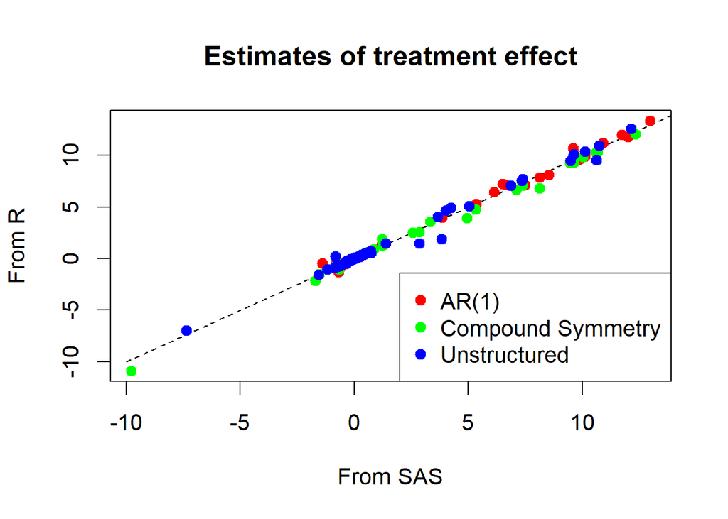

The widths of the confidence intervals produced by SAS and R were also plotted aginst each other

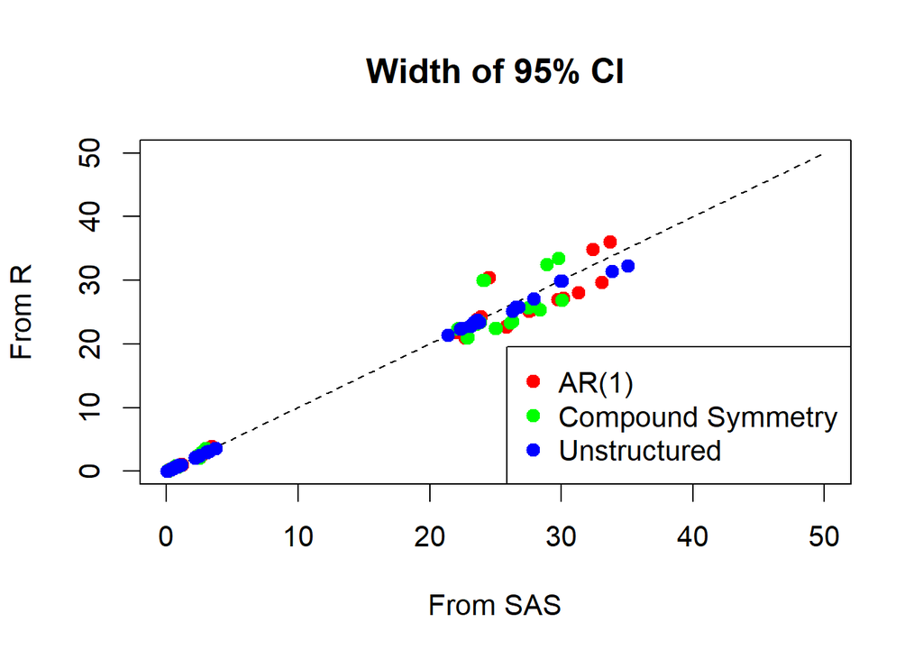

## R code using the lmer function

The repeated measures model with an unstructured covariance matrix can also be formulated as a random effect model and implemented using the lmer function from the lme4 package. This is shown below

```
mod1<-lmer(CHG ~ TRTP + AVISITN + TRTP:AVISITN + BASE + (0 + AVISITN | SUBJID),data=adlbh_1, control=lmerControl(check.nobs.vs.nRE="ignore"), na.action=na.omit)
```

## Comparison between SAS and R using the lmer function

We then graphically compared the results from SAS with the results from R using the lmer function. Again, estimates of treatment effect and width of confidence intervals were plotted against each other.

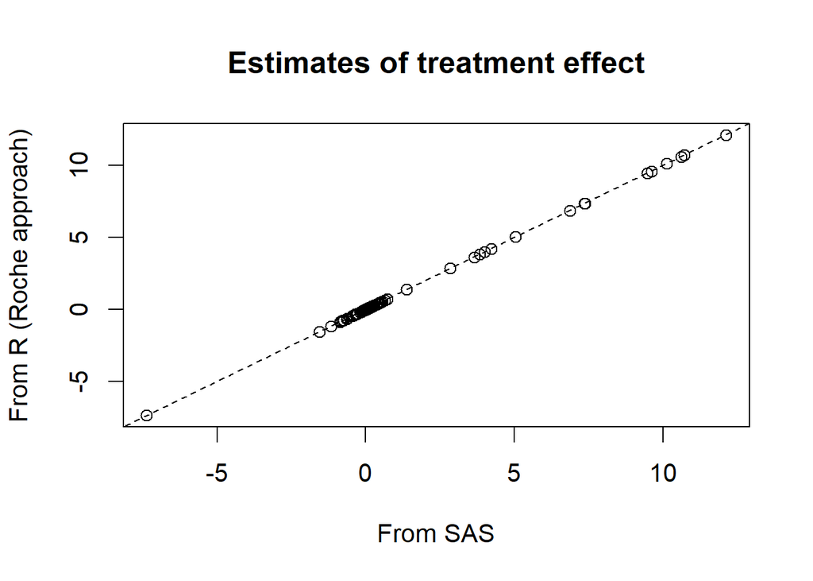

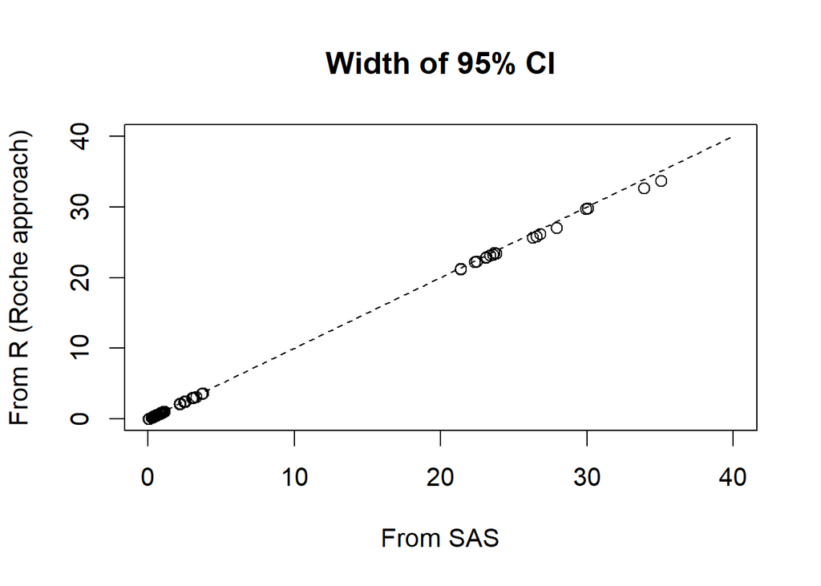

## Future work

- Run SAS code by also removing assessments at avisitn=0 from the response variable, and using trtp (or trtpn) and avisit (or avisitn)
- Investigating the differences
- Implement lmer equivalent to MMRM with compound symmetry
- Comparisons for other models, i.e. only random, random and repeated, no repeated